# Bus Waiting Time Observation Story

## Introduction: observing bus trips

This visual data story explores bus trip observations collected using a Google Form. Each row in the data represents one bus observation. The data was collected by observing real bus trips rather than asking people for their opinions.

The observations include the time of day, day type, waiting time, crowding level, whether the bus was on time, the weather, and the number of people waiting at the bus stop.

The main goal of this story is to understand which conditions may be linked with longer or shorter bus waiting times.

## How waiting time changes by time of day

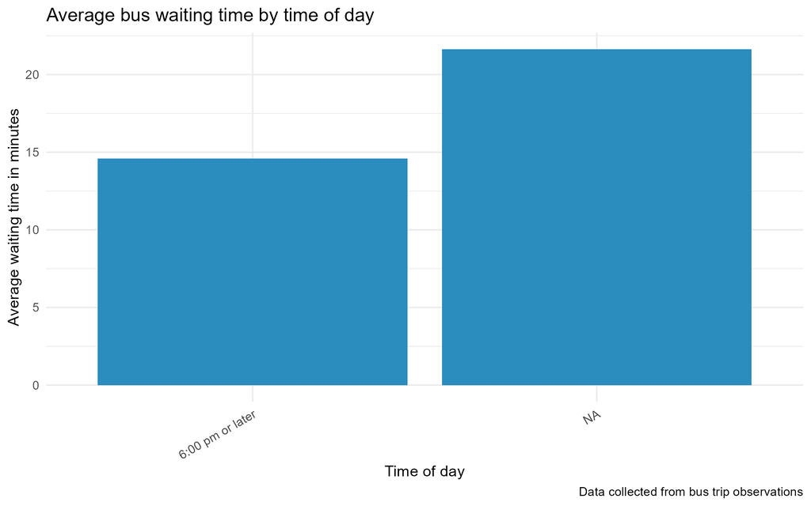

## How waiting time relates to bus punctuality

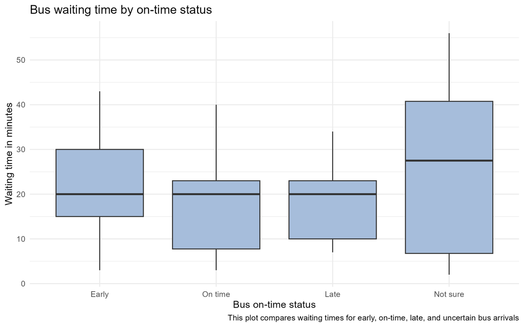

A boxplot showing bus waiting time grouped by whether the bus was early, on time, late, or not sure.

This chart compares bus waiting time with the bus on-time status.

The boxplot is useful because it shows the spread of waiting times, not just one single average. This helps compare whether buses recorded as **late** tend to have longer or more variable waiting times than buses recorded as **early** or **on time**.

This supports the visual story by showing whether bus punctuality appears to be connected with the experience of waiting.

## Waiting time across observation timestamps

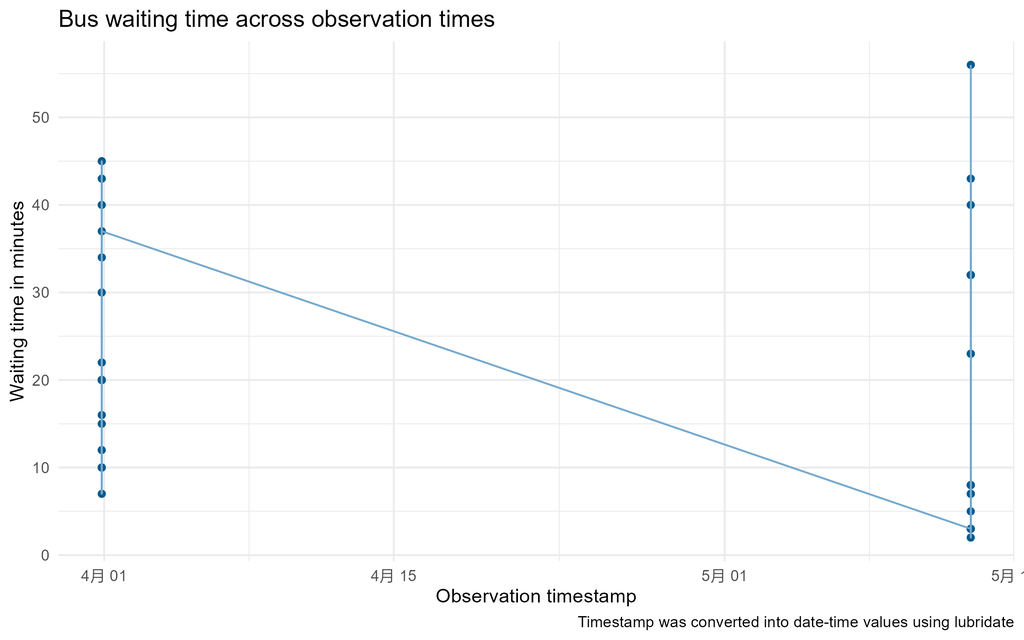

A point and line chart showing bus waiting time across observation timestamps. Each point represents one bus observation.

This chart uses the **timestamp** from the logged data. The timestamp was converted into date-time values using the `{lubridate}` package.

This visualisation shows how waiting time changed across the sequence of observations. It can help reveal whether there were unusual observations with especially long waits, or whether waiting times were mostly stable across the data collection period.

Using timestamp data is important because it connects the observations to when they were recorded.

## Conclusion

The data is useful because it is based on direct observation. Instead of asking people for opinions, each response records what was observed during a bus trip. This makes the data suitable for exploring real patterns in bus waiting time and public transport reliability.